# Diversity | Free Full-Text | Diversity and Distribution of the Dominant Ant Genus Anonychomyrma (Hymenoptera: Formicidae) in the Australian Wet Tropics

Diversity

All Article Types

Advanced Search

[Journals](https://www.mdpi.com/about/journals)

[Diversity](https://www.mdpi.com/journal/diversity)

[Volume 12](https://www.mdpi.com/1424-2818/12)

[Issue 12](https://www.mdpi.com/1424-2818/12/12)

10.3390/d12120474

[figure not shown]

## Article Menu

Full-Text Views 89

[figure not shown]

[figure not shown]

0

*textsms*

0

Open AccessArticle

# Diversity and Distribution of the Dominant Ant Genus Anonychomyrma (Hymenoptera: Formicidae) in the Australian Wet Tropics

by

Lily Leahy

<sup>1,*</sup>,

Brett R. Scheffers

<sup>2</sup>,

Stephen E. Williams

<sup>1</sup> and

Alan N. Andersen

<sup>3</sup>

<sup>1</sup>

Centre for Tropical Environmental and Sustainability Science, College of Science and Engineering, James Cook University, Townsville, QLD 4811, Australia

<sup>2</sup>

Department of Wildlife Ecology and Conservation, University of Florida, Gainesville, FL 32611, USA

<sup>3</sup>

Research Institute for the Environment and Livelihoods, Charles Darwin University, Darwin, NT 0909, Australia

Author to whom correspondence should be addressed.

*Diversity* **2020**, *12*(12), 474; https://doi.org/10.3390/d12120474

Received: 18 November 2020 / Revised: 6 December 2020 / Accepted: 7 December 2020 / Published: 14 December 2020

(This article belongs to the Special Issue [Diversity, Biogeography and Community Ecology of Ants](https://www.mdpi.com/journal/diversity/special_issues/Ants))

[View Full-Text](https://www.mdpi.com/1424-2818/12/12/474/htm) [Download PDF](https://www.mdpi.com/1424-2818/12/12/474/pdf)

Browse Figures

Cite This Paper

## Abstract

Anonychomyrma is a dolichoderine ant genus of cool-temperate Gondwanan origin with a current distribution that extends from the north of southern Australia into the Australasian tropics. Despite its abundance and ecological dominance, little is known of its species diversity and distribution throughout its range. Here, we describe the diversity and distribution of Anonychomyrma in the Australian Wet Tropics bioregion, where only two of the many putative species are described. We hypothesise that the genus in tropical Australia retains a preference for cool wet rainforests reminiscent of the Gondwanan forests that once dominated Australia, but now only exist in upland habitats of the Wet Tropics. Our study was based on extensive recent surveys across five subregions and along elevation and vertical (arboreal) gradients. We integrated genetic (CO1) data with morphology to recognise 22 species among our samples, 20 of which appeared to be undescribed. As predicted, diversity and endemism were concentrated in uplands above 900 m a.s.l. Distribution modelling of the nine commonest species identified maximum temperature of the warmest month, rainfall seasonality, and rainfall of the wettest month as correlates of distributional patterns across subregions. Our study supported the notion that Anonychomyrma radiated from a southern temperate origin into the tropical zone, with a preference for areas of montane rainforest that were stably cool and wet over the late quaternary. [View Full-Text](https://www.mdpi.com/1424-2818/12/12/474/htm)

*Keywords:* [ant diversity](https://www.mdpi.com/search?q=ant%20diversity); biogeography; [species delimitation](https://www.mdpi.com/search?q=species%20delimitation); Dolichoderinae; [species distribution models](https://www.mdpi.com/search?q=species%20distribution%20models); [climatic gradients](https://www.mdpi.com/search?q=climatic%20gradients); [wet tropics](https://www.mdpi.com/search?q=wet%20tropics); [climate change](https://www.mdpi.com/search?q=climate%20change)

▼ Show Figures

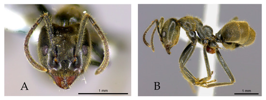

Figure 1

This is an open access article distributed under the [Creative Commons Attribution License](https://creativecommons.org/licenses/by/4.0/) which permits unrestricted use, distribution, and reproduction in any medium, provided the original work is properly cited

## Supplementary Material

- **Supplementary File 1:**

  [PDF-Document](https://www.mdpi.com/1424-2818/12/12/474/s1) (PDF, 1057 KiB)

[figure not shown]

## Share and Cite

**MDPI and ACS Style**

Leahy, L.; Scheffers, B.R.; Williams, S.E.; Andersen, A.N. Diversity and Distribution of the Dominant Ant Genus *Anonychomyrma* (Hymenoptera: Formicidae) in the Australian Wet Tropics. *Diversity* **2020**, *12*, 474.

Show more citation formats

Note that from the first issue of 2016, MDPI journals use article numbers instead of page numbers. See further details [here](https://www.mdpi.com/about/announcements/784).

## Article Metrics

### Citations

Crossref

0

Google Scholar

[click to view]

### Article Access Statistics

[figure not shown]

For more information on the journal statistics, click [here](https://www.mdpi.com/journal/diversity/stats).

Multiple requests from the same IP address are counted as one view.

## Related Articles

   Andersen, Alan N. et al., Diversity, 2016
3. [Marine Biodiversity in Temperate Western Australia: Multi-Taxon Surveys of Minden and Roe Reefs](https://www.mdpi.com/1424-2818/8/2/7?utm_source=TrendMD&utm_medium=cpc&utm_campaign=Diversity_TrendMD_0)

   Zoe Richards et al., Diversity, 2016
4. [Ants in Australia’s Monsoonal Tropics: CO1 Barcoding Reveals Extensive Unrecognised Diversity](https://www.mdpi.com/1424-2818/10/2/36?utm_source=TrendMD&utm_medium=cpc&utm_campaign=Diversity_TrendMD_0)

   Xue et al., Plant Diversity, 2020
2. [Identifying climate refugia for 30 Australian rainforest plant species, from the last glacial maximum to 2070](https://link.springer.com/article/10.1007/s10980-019-00924-6?utm_campaign=SRLF_AWA_TR01_GL_10980_HP_TrendMDQ420&utm_content=null&utm_medium=cpc&utm_source=trendmd)

   Sourav Das et al., Landscape Ecology, 2019
3. [Phytosociology of stratification in a lowland tropical rainforest occurring north of the Tropic of Cancer in Meghalaya, India](https://www.sciencedirect.com/science/article/pii/S2468265919300381?utm_source=TrendMD&utm_medium=cpc&utm_campaign=Plant_Diversity_TrendMD_1)

   Precision Oncology News, 2019

[Powered by](https://www.trendmd.com/how-it-works-readers)

**Search more from Scilit**

Search

*[Diversity](https://www.mdpi.com/journal/diversity)*, EISSN 1424-2818, Published by MDPI Disclaimer

The statements, opinions and data contained in the journal are solely those of the individual authors and contributors and not of the publisher and the editor(s). MDPI stays neutral with regard to jurisdictional claims in published maps and institutional affiliations.

[RSS](https://www.mdpi.com/rss/journal/diversity) [Content Alert](https://www.mdpi.com/journal/diversity/toc-alert)

### Follow MDPI

[LinkedIn](https://www.linkedin.com/company/mdpi) [Facebook](https://www.facebook.com/MDPIOpenAccessPublishing) [Twitter](https://twitter.com/MDPIOpenAccess)

Subscribe to receive issue release notifications and newsletters from MDPI journals

© 1996-2020 MDPI (Basel, Switzerland) unless otherwise stated

Disclaimer

[Terms and Conditions](https://www.mdpi.com/about/terms-and-conditions) [Privacy Policy](https://www.mdpi.com/about/privacy)